# Practical Machine Learning

Course Project

Ivan Millanes

5/12/2020

This is the Project for the [Practical Machine Learning](https://www.coursera.org/learn/practical-machine-learning) Course, which is part of Coursera’s [Data Science Specialization](https://www.coursera.org/specializations/jhu-data-science).

# Background

Using devices such as *Jawbone Up*, *Nike FuelBand*, and *Fitbit* it is now possible to collect a large amount of data about personal activity relatively inexpensively. These type of devices are part of the quantified self movement – a group of enthusiasts who take measurements about themselves regularly to improve their health, to find patterns in their behavior, or because they are tech geeks.

One thing that people regularly do is quantify *how much* of a particular activity they do, but they rarely quantify *how well* they do it. In this project, the goal is to use data from accelerometers on the belt, forearm, arm, and dumbell of 6 participants. They were asked to perform barbell lifts correctly and incorrectly in 5 different ways. For [more information](http://groupware.les.inf.puc-rio.br/har), see the section on the Weight Lifting Exercise Dataset.

# Data

The data for this project come from [this](http://groupware.les.inf.puc-rio.br/har) source.

# Getting and Cleaning Data

I load libraries to be used.

```r
library(tidyverse)
library(caret)
library(ggcorrplot)
```

I download and save the data.

```r
if (!file.exists("data/pml-training.csv")) {
      trainURL <- "https://d396qusza40orc.cloudfront.net/predmachlearn/pml-training.csv"
      download.file(trainURL,
              destfile = "data/pml-training.csv")
}

if (!file.exists("data/pml-testing.csv")) {
      testURL <- "https://d396qusza40orc.cloudfront.net/predmachlearn/pml-testing.csv"
      download.file(testURL,
                    destfile = "data/pml-testing.csv")
}
```

I load the data into R.

```r
# Read Data
training <- read_csv("data/pml-training.csv")
testing <- read_csv("data/pml-testing.csv")
```

## Training data set

The training data set is going to be used to fit and assess the model. It consists of 19622 observations and 160 variables. One of those variables, `classe`, is the output.

## Testing data set

This data set consists of 20 new observations, which have to be classified. The observations on this data set don’t have the `classe` they belong.

## Data slicing

The `training` data set has the labels for the output.

I’ll split this data set in two:

- `train`, which is going to be used to train the model.
- `test`, which instead of being used to train the model, it’s going to be used to assess the accuracy of the model selected with the `train` data set. This data set will only be used once, and won’t influence the model we choose.

70% of `training` data is going to be used for `train`, while the other 30% will be used for `test`.

```r
# Set seed
set.seed(123123)

inTrain <- createDataPartition(y = training$classe, p = 0.70, list=FALSE)
train <- training[inTrain, ]
test <- training[-inTrain, ]
```

This way, `train` has 13737 observations, while `test` has the remaining 5885

## Selecting variables

### ID Variables

To fit the model, I won’t be using ID variables.

```r
# Remove ID Variables (X1, user_name)
train$X1 <- NULL
train$user_name <- NULL
train$num_window <- NULL
```

### Time Variables

Also, in order to simplify the analysis, I delete variables related to `time`. In a more comprehensive analysis, perhaps it should be interesting to create new variables (for example, **day of the week** and/or **weekday or weekend flag**, **hour of the day** and/or **part of the day** -morning, afternoon, night-).

```r
# Remove Time Variables
train <- select(train, -contains("timestamp"))
```

### NA Values

After inspecting the `train` data set, I see that there are columns that have a lot of `NA` values. These columns won’t be useful when fitting the model, so I delete them.

The next code chunk defines a threshold (90%), and deletes all variables that have at least that percentage of `NA` values.

The definition of that threshold comes from the fact that for this particular data set, we have a group of variables without `NA` values, and another group with a percentage of `NA` values greater than 90%. This threshold may be different for different problems.

```r
# Used to calculate %
nrow <- nrow(train)

# Set threshold
threshold = 90

# Set of variables with low NA %
low_na_pct <- map(train, function(x){
      sum(is.na(x))/nrow * 100
}) %>%
      as_tibble %>%
      pivot_longer(cols = everything(),
                   names_to = "variable",
                   values_to = "na_pct") %>%
      filter(na_pct < threshold)

# Select Variables with low NA % (Delete Variables with high NA %)
train <- train %>%
      select(low_na_pct$variable)
```

### Near Zero Variables

In this section I’ll use the [nearZerovar](https://www.rdocumentation.org/packages/caret/versions/6.0-76/topics/nearZeroVar) function of the `caret` package in order to identify and remove Near Zero Variance Predictors.

```r
# Keep Non-Near Zero Variance Predictors
nzv <- nearZeroVar(train, saveMetrics = TRUE) %>%
      rownames_to_column("variable") %>%
      filter(nzv == FALSE)

train <- train %>%
      select(nzv$variable)
```

## Correlation analysis

Right now, the `train` data set contains 52 predictor variables. I believe that some of them might be correlated with each other. If that’s the case, I’ll use Principal Components Analysis (PCA) to reduce the dimensionality.

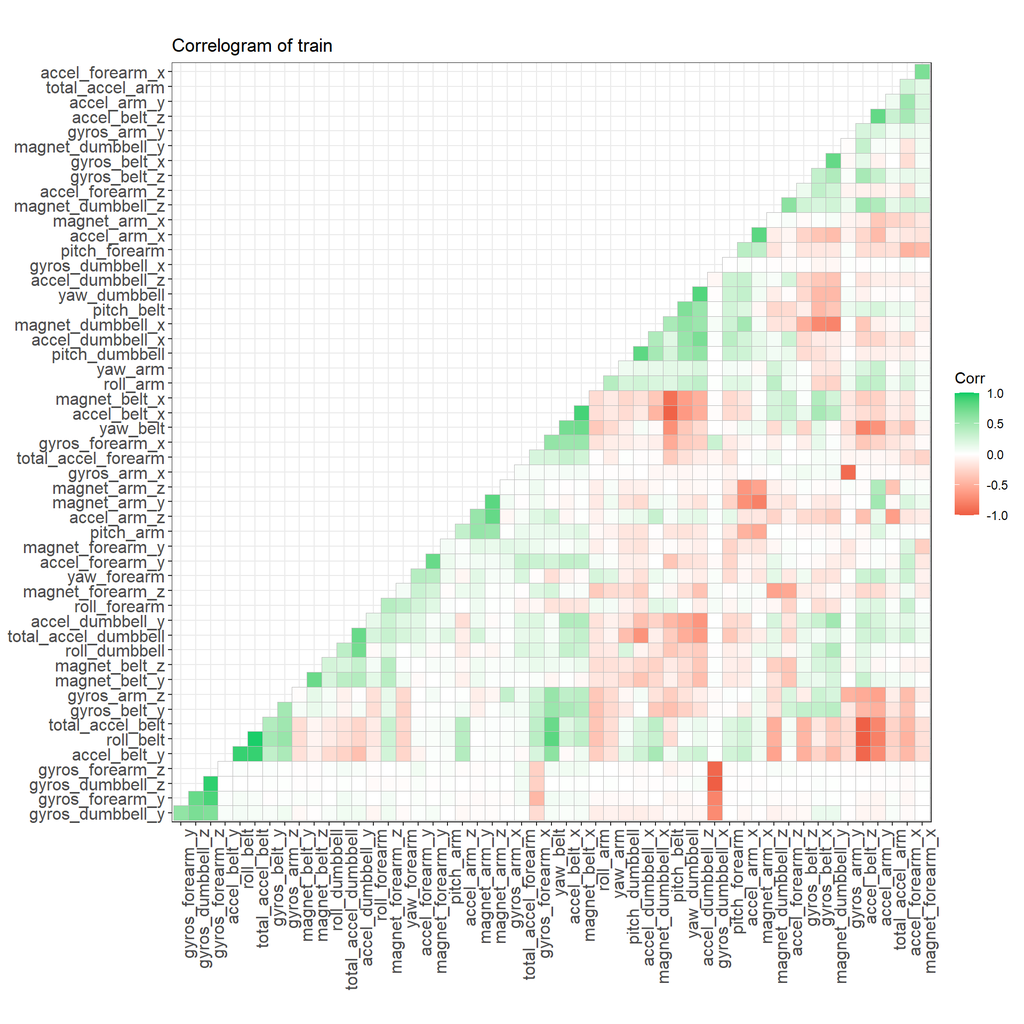

```r
# Covariates Correlation Analysis
correlations = cor(select(train, roll_belt:magnet_forearm_z))

# Plot
ggcorrplot(correlations, hc.order = TRUE,
           type = "lower",
           colors = c("tomato2", "white", "springgreen3"),
           title="Correlogram of train",
           ggtheme=theme_bw) +
      theme(axis.text.x = element_text(angle = 90, hjust = 1))
```

In the Figure above we see that some of the variables are correlated with each other. For that reason, I’ll use PCA. Also, I’d like to practice this application using the `caret` package.

## Principal Components Analysis

In the code below I set `thresh = 0.85`, meaning that I’ll choose a number of PC that keep at least 85% of the total variance.

```r
PCA <- preProcess(select(train, roll_belt:magnet_forearm_z),
                      method = "pca",
                      thresh = 0.85)
PCA
```

```
## Created from 13737 samples and 52 variables
##
## Pre-processing:
##   - centered (52)
##   - ignored (0)
##   - principal component signal extraction (52)
##   - scaled (52)
##
## PCA needed 15 components to capture 85 percent of the variance
```

PCA needed 15 components to capture 85 percent of the variance.

```r
train_pc <- predict(PCA, train)
```

# Model Fitting

The model will be fit using the `train_pc` data set.

I’ll use Random Forest, because it’s a good technique to start.

I’ll use a 10 fold cross-validation, repeated 3 times.

```r
# 10 folds cv, repeat 3 times
control <- trainControl(method='repeatedcv',
                        number=10,
                        repeats=3)

# Random Forest Fit
fit_RF <- train(classe ~ .,
            method = "rf",
            data = train_pc,
            trControl=control)
```

```r
fit_RF
```

```
## Random Forest
##
## 13737 samples
##    15 predictor
##     5 classes: 'A', 'B', 'C', 'D', 'E'
##
## No pre-processing
## Resampling: Cross-Validated (10 fold, repeated 3 times)
## Summary of sample sizes: 12364, 12361, 12363, 12363, 12366, 12363, ...
## Resampling results across tuning parameters:
##
##   mtry  Accuracy   Kappa
##    2    0.9647422  0.9553980
##    8    0.9600580  0.9494863
##   15    0.9557629  0.9440578
##
## Accuracy was used to select the optimal model using the largest value.
## The final value used for the model was mtry = 2.
```

The accuracy in the `train_pc` data set is 0.9647, which is achieved setting the parameter `mtry = 2`.

I feel okey with this results, but now I want to estimate the accuracy with data that was not used to train the model. This is when we use the `test` data set. Remember that we need to apply PCA to this data as well in order to use our model.

```r
# PCA on test data
test_pc <- predict(PCA, test)
```

```r
# Test accuracy
confusionMatrix(as.factor(test$classe), predict(fit_RF,test_pc))
```

```
## Confusion Matrix and Statistics
##
##           Reference
## Prediction    A    B    C    D    E
##          A 1652    4   10    7    1
##          B   28 1084   24    0    3
##          C    4   15  990   15    2
##          D    3    2   57  898    4
##          E    2    7    7    9 1057
##
## Overall Statistics
##
##                Accuracy : 0.9653
##                  95% CI : (0.9603, 0.9699)
##     No Information Rate : 0.287
##     P-Value [Acc > NIR] : < 2.2e-16
##
##                   Kappa : 0.9561
##
##  Mcnemar's Test P-Value : 1.13e-08
##
## Statistics by Class:
##
##                      Class: A Class: B Class: C Class: D Class: E
## Sensitivity            0.9781   0.9748   0.9099   0.9666   0.9906
## Specificity            0.9948   0.9885   0.9925   0.9867   0.9948
## Pos Pred Value         0.9869   0.9517   0.9649   0.9315   0.9769
## Neg Pred Value         0.9912   0.9941   0.9798   0.9937   0.9979
## Prevalence             0.2870   0.1890   0.1849   0.1579   0.1813
## Detection Rate         0.2807   0.1842   0.1682   0.1526   0.1796
## Detection Prevalence   0.2845   0.1935   0.1743   0.1638   0.1839
## Balanced Accuracy      0.9864   0.9816   0.9512   0.9767   0.9927
```

The accuracy in the `test` set is 0.965.

I might try fitting other models, for example, using the original variables instead of the PC or using other techniques such as gbm. I should’t use `test` data to compare the models, because if I do that, I’m using `test` to choose the model and I no longer have an estimate of the accuracy using data that was not part of the model fitting. If I were to try more models, I should divide `training` data set into three: `train`, `validation` and `test` sets. Then, I can use `train` to train the different models, `validation` to choose between them and `test` to assess it in data that was not used to fit it.

# Predictions

Using the fitted model, I’ll predict the output for the observations in `testing`. Remember to apply PCA before using the `predict` function.

```r
testing_pc <- predict(PCA, testing)
predict(fit_RF,testing_pc)
```

```
##  [1] B A B A A E D B A A B C B A E E A B B B
## Levels: A B C D E
```

# Summary

I divided `training` data set into two, `train` and `test`.

I used `train` to fit the model.

I removed ID and “time” variables.

I removed variables with high percentage of NA values and checked that the predictors didn’t have near zero variance.

Then, with the remaining variables I applied PCA and I kept with 15 PC, capturing 85 percent of the variance.

I used Random Forest to fit the model, using 10 fold cross-validation repeated 3 times. The best result were obtained using `mtry = 2`.

The accuracy in the `test` set was 0.965.